# Analyse des déterminants du loyer à Rennes

**NOM - Prénom**

[**Master 1 MAS - Université de Rennes**](https://eco.univ-rennes.fr/master-mathematiques-appliquees-statistique)

**ou**

[**Master 1 MAS - Université Rennes 2**](https://formations.univ-rennes2.fr/fr/formations/master-37/master-mention-mathematiques-appliquees-statistique-parcours-sciences-des-donnees-intelligence-artificielle-JFTJBMKM.html)

# 1. Introduction

L’accès au logement constitue aujourd’hui un enjeu socio-économique majeur en France. Dans un contexte de pression croissante sur le marché locatif, notamment dans les villes à forte attractivité universitaire comme Rennes, les ménages sont confrontés à une hausse soutenue des loyers. Comprendre les facteurs qui influencent le prix des logements devient alors essentiel pour analyser les disparités territoriales et éclairer les décisions des acteurs publics.

Dans ce projet, nous cherchons à analyser empiriquement les **déterminants du loyer tout compris** des logements situés à Rennes, en utilisant des données collectées automatiquement par web scraping sur le site *Ouest-France Immo*. L’étude se concentre sur les logements qui sont répartis dans quatre grands secteurs de Rennes : **Centre**, **Ouest**, **Nord-Est** et **Nord-Ouest**.

## 1.1 Contexte et problématique

Le marché rennais est particulièrement dynamique en raison de sa croissance démographique, de son attractivité étudiante et d’une offre locative limitée. Dès lors, une question centrale se pose :

> **Quels facteurs structurels expliquent les variations de loyer à Rennes ?**

Cela conduit à examiner l’effet de la surface, du nombre de pièces, des charges, de la performance énergétique et de la localisation géographique.

## 1.2 Motivation et intérêt du sujet

Ce travail présente plusieurs intérêts : - illustrer une application réelle de la **régression linéaire** à partir de données collectées soi-même ; - analyser les **disparités intra-urbaines** du marché locatif rennais ; - évaluer l’influence de caractéristiques structurelles ou environnementales du logement ; - proposer un exemple complet de démarche allant de la collecte de données au modèle final.

## 1.3 Questions de recherche et hypothèses

Les questions principales sont :

1. La surface influence-t-elle fortement le montant du loyer ?
2. Les charges intégrées modifient-elles significativement le niveau du loyer tout compris ?
3. La performance énergétique joue-t-elle un rôle dans la détermination du prix ?
4. Le quartier exerce-t-il un effet propre sur les niveaux de loyer ?

Les hypothèses qui en découlent sont :

- **H1 :** une surface plus élevée entraîne un loyer plus élevé
- **H2 :** des charges plus importantes augmentent le loyer tout compris
- **H3 :** une meilleure performance énergétique est associée à un loyer supérieur
- **H4 :** les logements du Centre sont plus chers que ceux des autres quartiers.

## 1.4 Objectifs du mémoire

Les objectifs du projet sont : - modéliser et expliquer le loyer mensuel tout compris ; - identifier les déterminants les plus significatifs ; - analyser les différences selon les quartiers rennais ; - proposer une interprétation économétrique rigoureuse.

## 1.5 Plan du document

Ce mémoire est structuré comme suit :

- **Section 1 : Introduction**
- **Section 2 : Cadre méthodologique**
- **Section 3 : Analyse descriptive des données**
- **Section 4 : Estimation et interprétation du modèle**
- **Section 5 : Conclusion**

# 2. Cadre méthodologique

Cette section présente le modèle économétrique utilisé et les choix méthodologiques qui guident l’estimation.

## 2.1 Choix méthodologiques : régression linéaire et MCO

Le modèle retenu est une **régression linéaire multiple**, estimée à l’aide de la méthode des **Moindres Carrés Ordinaires (MCO)**. Cette approche permet d’étudier comment une variable quantitative , ici le loyer tout compris dépend de plusieurs caractéristiques propres au logement.

La méthode MCO consiste à minimiser la somme des carrés des écarts entre les valeurs observées et celles prédites par le modèle. Cette méthode est privilégiée pour sa simplicité, son interprétabilité et les propriétés de ses estimateurs.

## 2.2 Formulation du modèle

La variable expliquée est le **loyer mensuel tout compris** (en euros).

Les variables explicatives sont :

- la **surface** du logement (m²),
- les **charges comprises** (euros),
- le **nombre de pièces**,
- la **classe énergétique** (A, B, C, …),
- la **consommation énergétique annuelle** (kWh/an),
- les **émissions de CO₂** (kg/an),
- le **quartier** (Centre, Ouest, Nord-Est, Nord-Ouest).

Le modèle général s’écrit :

$$\text{Loyer}_i = \beta_0 +
\beta_1 \text{Surface}_i +
\beta_2 \text{Charges}_i +
\beta_3 \text{Pièces}_i +
\beta_4 \text{ClasseÉnergie}_i +
\beta_5 \text{Consommation}_i +
\beta_6 \text{ÉmissionsCO2}_i +
\sum_q \gamma_q \text{Quartier}_{qi} +
\varepsilon_i$$

où : - $\beta_0$ est la constante

- $\beta_j$ mesure l’effet marginal de chaque caractéristique
- $\gamma_q$ capture l’effet des quartiers par rapport à un quartier de référence
- $\varepsilon_i$ est le terme d’erreur

## 2.3 Justification des choix techniques

Plusieurs éléments motivent ce cadre :

- La régression linéaire est un outil adapté pour analyser les facteurs influençant une variable économique.
- La méthode MCO fournit des estimateurs robustes et facilement interprétables.
- L’utilisation de **variables indicatrices** pour les quartiers permet de mettre en évidence les différences géographiques de prix.
- L’intégration des variables énergétiques répond aux enjeux actuels de performance environnementale.
- Le modèle permet de mesurer l’effet propre de chaque variable tout en contrôlant les autres.

# 3. Analyse des données

## 3.1 Cadre des données

Les données proviennent du site **Ouest-France Immo**, collectées à l’aide d’un script de web scraping. Elles décrivent des logements mis en location dans la **ville de Rennes**, .

L’étude porte sur **quatre secteurs géographiques** :

- Quartiers Centre
- Quartiers Ouest
- Quartiers Nord-Est
- Quartiers Nord-Ouest

Chaque ligne du jeu de données correspond à **une annonce unique**.  
Les variables collectées décrivent :

- Les caractéristiques du logement (surface, nombre de pièces, charges)
- Sa performance énergétique (classe, consommation, émissions)
- Sa localisation.

### a) Importation des données

|  | Loyer_TTC | Surface | Charges | Pièces | Pièce | label_eco | kWh | kgCO2 | Quartiers |
| --- | --- | --- | --- | --- | --- | --- | --- | --- | --- |
| 1 | 278 | 19 | NA | NA | 1 | D | 247 | 49 | Quartiers Nord-Est |
| 2 | 343 | 17 | 15 | NA | 1 | E | 322 | 9 | Quartiers Nord-Est |
| 3 | 345 | 9 | 80 | NA | 1 | C | 230 | 7 | Quartiers Nord-Ouest |
| 4 | 350 | 17 | 10 | NA | 1 | D | 248 | 40 | Quartiers Nord-Ouest |
| 5 | 359 | 15 | 20 | NA | 1 | F | 367 | 21 | Quartiers Centre |

### b) Description des variables

Tableau 1 : Description des variables

| Code.de.la.série | Définition | Unité | Source |
| --- | --- | --- | --- |
| prix_TCC | Loyer mensuel tout compris | Euros | Ouest-France Immo (web scraping) |
| Surface | Surface habitable du logement | m² | Ouest-France Immo (web scraping) |
| Charges | Montant des charges mensuelles | Euros | Ouest-France Immo (web scraping) |
| Pieces | Nombre de pièces du logement | Nombre | Ouest-France Immo (web scraping) |
| label_eco | Classe énergétique du logement | Catégorie (A–G) | Ouest-France Immo (web scraping) |
| kWh | Consommation énergétique annuelle | kWh/an | Ouest-France Immo (web scraping) |
| kgCO2 | Émissions annuelles de CO2 | kg/an | Ouest-France Immo (web scraping) |
| Quartiers | Secteur géographique du logement | Nom du quartier | Ouest-France Immo (web scraping) |

## 3.2 Prétraitement et nettoyage des données

Avant de procéder aux analyses descriptives et économétriques, il a été nécessaire de réaliser un travail approfondi de préparation des données issues du web scraping. Comme souvent avec des données collectées directement sur un site d’annonces, plusieurs problèmes se présentent : valeurs manquantes, incohérences, doublons, hétérogénéité dans les formats ou dans les catégories. Cette section présente de manière structurée l’ensemble des opérations réalisées pour obtenir un jeu de données exploitable.

### a)Sélection et renommage des variables

Dans un premier temps, seules les variables pertinentes pour l’étude ont été conservées.  
Les colonnes correspondant “Loyer”, “Surface.habitable”, “Dont.charges”,“Pièces” , “Pièce”, “label_eco”, “kWh.m…an”,“kgCO2.m…an”, “Quartiers” ont été extraites.  
Les noms ont également été standardisés pour faciliter leur manipulation (par exemple : renommer *Surface habitable* en *Surface*, *Dont charges* en *Charges*, etc.).

### b) Corriger les valeurs manquantes et modéliser les niveaux

#### b.1 Modéliser les niveaux

**Découper le Loyer TTC en facteur**

```r
seuil <-  quantile(annonces$Loyer_TTC ,probs = seq(0, 1, 0.25))
annonces$Loyer_Groupe <- cut(annonces$Loyer_TTC , breaks = seuil , include.lowest = TRUE)
```

**Exclusion des annonces non classées énergétiquement** : les logements portant la mention *NC* (Non Classé) ont été retirés.

**Avant traitement**

```r
table(annonces$label_eco)
```

```
##
##  A  B  C  D  E  F  G NC
##  2  6 41 73 44 14  1 24
```

- **Regroupement de certaines catégories énergétiques** : les labels *G*, *A* , *B* et *C* ont été regroupés dans une catégorie commune (*C+*) et les labels *E* et *F* ont été regroupés dans une catégorie commune (*E-*) pour éviter des classes trop peu représentées.

```
## [1] "C+" "D"  "E-"
```

[output not shown]

**Apres traitement**

```
##
##  1  2  3
## 50 73 58
```

#### b.2 One Hot Encoding des variables qualitatives

```
  **Quartiers **
```

```r
#install.packages("fastDummies")
library(fastDummies)

annonces <- dummy_cols(annonces, select_columns = "Quartiers")
annonces <- annonces%>% select(c(1:10) , "Centre"=`Quartiers_Quartiers Centre` , "Nord_Est" = `Quartiers_Quartiers Nord-Est` ,
                               "Nord_Ouest" = `Quartiers_Quartiers Nord-Ouest` , "Ouest" = `Quartiers_Quartiers Ouest`)
```

#### b.3 Correction des valeurs manquante

- **Correction des pièces manquantes** : Le jeu de données contient deux variables liées au nombre de pièces du logement :
- **Pièces** : prend une valeur manquante (`NA`) ou bien un nombre de pièces **strictement supérieur à 1** ;
- **Piece** : variable binaire prenant la valeur `1` ou `NA`, et renseignée uniquement lorsque `Pièces` est manquante. Finalement, nous avons remplacé toutes les valeurs manquantes par 1 (1 pièce).
- **Imputation énergétique** : les valeurs manquantes concernant la consommation en kWh et les émissions de CO₂ ont été remplacées par la moyenne calculée au sein de chaque classe énergétique.  
  Cela permet une imputation cohérente avec le profil énergétique du logement.

Ces opérations permettent d’éviter la perte excessive d’observations tout en conservant une cohérence structurelle entre les variables.

**Remplacer des valeurs manquantes dans les charges**

### c) Vérification des effectifs et cohérence interne

Les effectifs par label énergétique ont été inspectés pour vérifier la répartition des logements après nettoyage.  
Cette étape permet de s’assurer que les regroupements effectués ne créent pas de déséquilibres majeurs ou de classes trop petites.

Le travail consiste également à vérifier la cohérence logique des données, comme :

- absence de valeurs énergétiques impossibles,
- absence de surfaces irréalistes,
- cohérence entre loyer et charges.

Les observations incohérentes ont été retirées ou corrigées selon les cas.

**Vérification l’absence de valeur manquante**

```r
anyNA(annonces)
```

```
## [1] FALSE
```

### d) Constitution du jeu de données final

Après l’ensemble de ces traitements, la base obtenue présente les caractéristiques suivantes :

- absence de doublons,
- absence de valeurs cruciales manquantes,
- cohérence des formats (numérique, catégoriel, etc.),
- regroupement homogène des catégories énergétiques,
- estimation raisonnable des charges manquantes,
- structure compatible avec les outils de modélisation et d’analyse statistique.

Cette base nettoyée constitue le fondement de l’analyse descriptive (Section 3.3) et du modèle économétrique présenté dans la Section 4.

## 3.3 Analyse descriptive univariée des données

Cette section présente une description statistique des variables utilisées dans le modèle, après les étapes de nettoyage décrites précédemment.  
L’objectif est de caractériser la distribution de chacune des variables, d’identifier les tendances générales et de repérer d’éventuelles valeurs atypiques.  
L’analyse s’appuie sur des tableaux de statistiques descriptives ainsi que des représentations graphiques adaptées (histogrammes, boxplots, diagrammes en barres).

### a) Résumé statistique

Les principales variables quantitatives du jeu de données sont :

- le **loyer total** (euros),
- la **surface habitable** (m²),
- les **charges mensuelles** (euros),
- le **nombre de pièces**,
- la **consommation énergétique** (kWh/an),
- les **émissions de CO₂** (kg/an).

Le tableau suivant présente les statistiques descriptives classiques : moyenne, médiane, minimum, maximum et écart-type.

Tableau 2 : Statistiques descriptives des variables quantitatives

|  | Var | Min | Q1 | Median | Mean | Q3 | Max | SD |
| --- | --- | --- | --- | --- | --- | --- | --- | --- |
| Loyer_TTC | Loyer_TTC | 278 | 550 | 710.00 | 818.348066 | 1030 | 2250 | 365.6034059 |
| Surface | Surface | 9 | 22 | 35.00 | 46.530387 | 68 | 135 | 30.0541255 |
| Charges | Charges | 10 | 45 | 68.43 | 75.611216 | 90 | 300 | 49.9080296 |
| Pièces | Pièces | 1 | 1 | 2.00 | 2.215470 | 3 | 5 | 1.3511244 |
| label_eco | label_eco | 1 | 1 | 2.00 | 2.044199 | 3 | 3 | 0.7733276 |
| kWh | kWh | 37 | 159 | 219.00 | 221.735878 | 282 | 739 | 97.0364703 |
| kgCO2 | kgCO2 | 1 | 9 | 19.00 | 25.051732 | 37 | 96 | 18.7276770 |

### b) Statistiques descriptives des variables catégorielles

Les variables qualitatives retenues dans l’analyse sont :

- Le quartier du logement,
- La classe énergétique.
- Le tableau suivant présente la distribution des effectifs pour ces variables.
- Le group de loyer apres la modélisation

**Quartiers**

| Quartier | Freq |
| --- | --- |
| Quartiers Centre | 55 |
| Quartiers Nord-Est | 41 |
| Quartiers Nord-Ouest | 42 |
| Quartiers Ouest | 43 |

**Classe énergétique**

| Classe | Freq |
| --- | --- |
| 1 | 50 |
| 2 | 73 |
| 3 | 58 |

**Nombre de pièces**

| Pièces | Freq |
| --- | --- |
| 1 | 80 |
| 2 | 37 |
| 3 | 23 |
| 4 | 27 |
| 5 | 14 |

**Groupes de loyers**

| Groupe | Freq |
| --- | --- |
| [278,535] | 43 |
| (535,700] | 47 |
| (700,1e+03] | 44 |
| (1e+03,2.25e+03] | 47 |

**Interprétation** :

Les quatre tableaux obtenus après les étapes de nettoyage permettent d’apprécier la structure du jeu de données final. De manière générale, ils montrent que la base est désormais cohérente, équilibrée et prête pour l’analyse statistique.

L’histogramme permet de visualiser la distribution des variables quantitatives. Les graphiques suivants représentent :

#### La distribution du Loyer_TTC

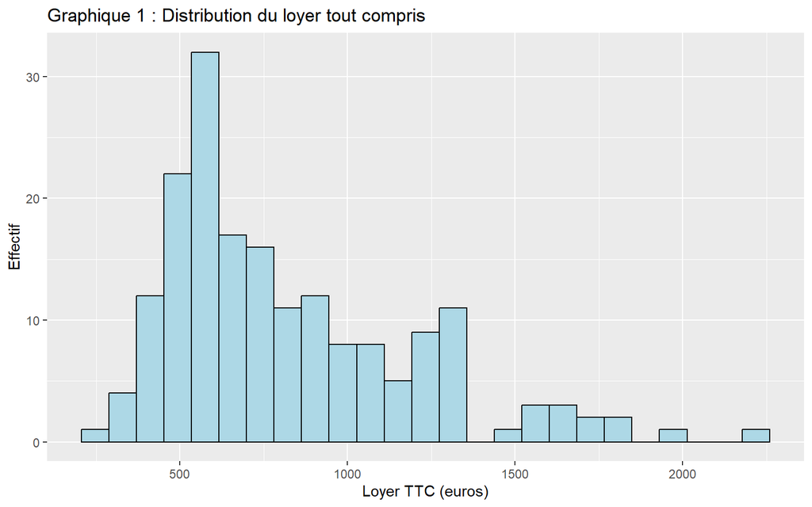

[figure not shown]

```r
library(ggplot2)
library(gridExtra)
#On peut aussi regarder les boxplots pour chaque variable pour avoir une idée rapide des quartiles.

graphConso.bp <- function(uneVariable){
  ggplot(data = annonces, aes_string(x = "factor(0)", y = uneVariable)) +
    geom_boxplot() + xlab("")
}
p1.bp <- graphConso.bp("Surface")
p2.bp <- graphConso.bp("Charges")
p3.bp <- graphConso.bp("Pièces")
p4.bp <- graphConso.bp("label_eco")
p5.bp <- graphConso.bp("kWh")
p6.bp <- graphConso.bp("kgCO2")



grid.arrange(p1.bp, p2.bp, p3.bp, p4.bp, p5.bp, p6.bp, ncol = 2)
```

#### La distribution des charges

**Relation globalement croissante**  
On observe une tendance générale à la hausse : lorsque les charges augmentent, le loyer total tend également à augmenter.  
Cela est cohérent avec le fonctionnement du marché locatif :  
- les logements plus grands ou mieux équipés ont généralement des charges plus élevées (eau, chauffage collectif, ascenseur, copropriété),  
- et un loyer total plus important.

**Dispersion importante pour les faibles charges**  
Pour des charges comprises entre 0 et 80 euros, les loyers apparaissent très dispersés (de 350 € à plus de 1500 €).  
Cela s’explique par le fait que deux logements ayant de faibles charges peuvent différer fortement en surface, en localisation ou en standing.  
Ainsi, les charges ne suffisent pas à elles seules pour expliquer le montant du loyer.

**Relation non linéaire et corrélation modérée**  
La dispersion du nuage montre que les charges ne permettent pas à elles seules de prédire précisément le loyer.  
La relation est positive mais relativement faible.  
Cela suggère que d’autres variables jouent un rôle déterminant : la surface, le quartier, la classe énergétique, le nombre de pièces, etc.  
Ceci justifie la mise en place d’un modèle de régression multiple intégrant plusieurs caractéristiques du logement.

#### La distribution du prix de Loyer selon nombre de Pieces.

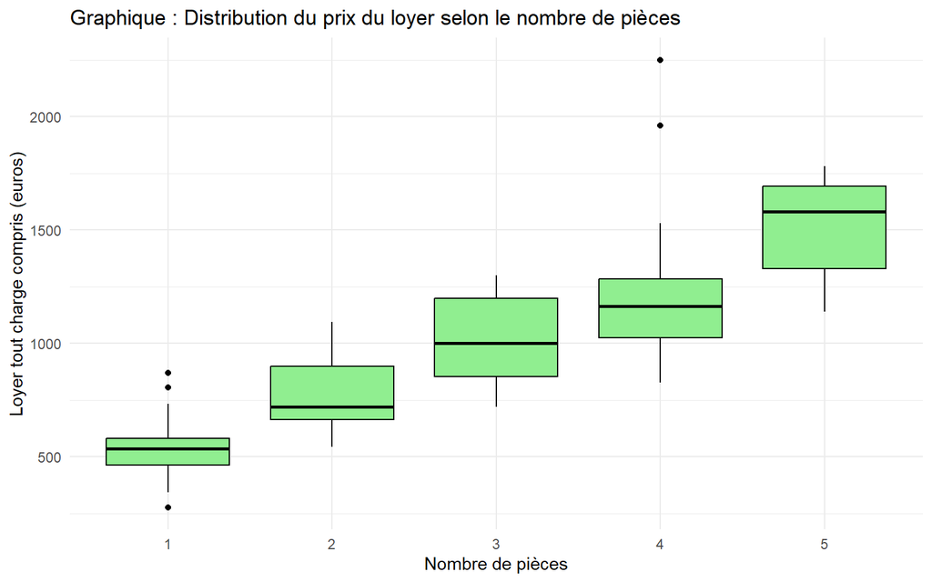

**Commentaire : Analyse du loyer selon le nombre de pièces**

**Hausse nette du loyer avec le nombre de pièces**  
Le boxplot montre une relation clairement croissante :  
plus le logement comporte de pièces, plus le loyer tout compris augmente.  
Cette tendance est attendue, car les appartements plus spacieux nécessitent un loyer plus élevé.

**Progression marquée entre chaque catégorie**  
À chaque passage d’une catégorie de pièces à la suivante (1 → 2, 2 → 3, etc.),  
la médiane du loyer augmente significativement.  
Cela confirme que le nombre de pièces constitue un déterminant majeur du niveau de loyer.

**Conclusion générale**  
Le graphique confirme que **le nombre de pièces est un facteur explicatif déterminant du loyer**.  
Il influence à la fois le niveau central du loyer (médiane) et sa dispersion.  
Ce constat justifie l’intégration de cette variable dans la régression linéaire comme variable explicative structurante.

## 3.4 Analyse descriptive bivariée des données

### Corrélation

#### 1ère règle: Coefficient de Corrélation

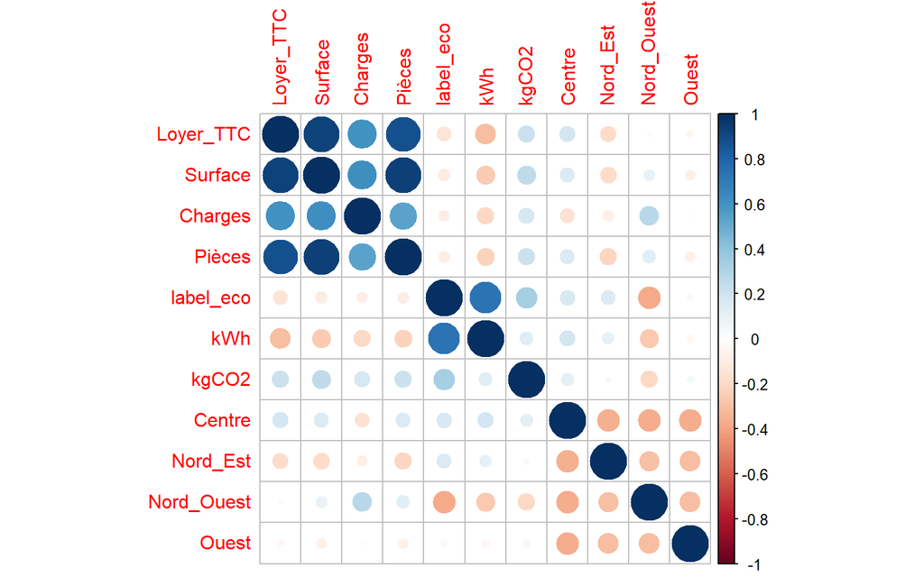

```r
library(corrplot)
vars_quanti <- annonces %>% select(-c(Quartiers , Loyer_Groupe))
corrplot(cor(vars_quanti), method="circle")
```

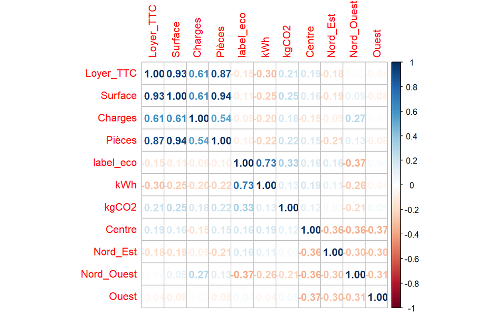

```r
corrplot(cor(vars_quanti), method="number")
```

**Commentaire : Corrélations entre le loyer et les variables explicatives**

Le tableau met en évidence plusieurs relations importantes entre la variable expliquée (*Loyer_TTC*) et les variables explicatives quantitatives :

1. **Surface (corr = 0.93)**  
   C’est la corrélation la plus forte observée.  
   Le loyer augmente très fortement avec la surface du logement.  
   Cette relation quasi linéaire confirme que la surface est le principal déterminant du prix.
2. **Nombre de pièces (corr = 0.87)**  
   Le nombre de pièces est également fortement corrélé au loyer.  
   Cela s’explique naturellement par le fait qu’un logement comportant plus de pièces possède généralement une surface plus importante et un niveau de confort supérieur.
3. **Charges (corr = 0.61)**  
   Une corrélation positive modérée :  
   les logements ayant des charges plus élevées ont souvent des loyers plus élevés.  
   Cependant, la relation est moins forte que pour la surface et les pièces.
4. **Consommation énergétique kWh (corr = –0.30)**  
   La corrélation est faible et négative.  
   Cela suggère que les logements très énergivores (kWh élevés) ont tendance à être légèrement moins chers, ce qui est cohérent avec l’idée qu’un mauvais bilan énergétique peut réduire la valeur locative.
5. **Émissions de CO₂ (corr = 0.21)**  
   Corrélation faible et positive.  
   Cela signifie qu’il n’existe pas de relation claire entre les émissions de CO₂ et le montant du loyer.  
   Le CO₂ est probablement un facteur indirect qui reflète davantage la performance énergétique ou la taille du logement.

Si la valeur absolue du coefficient de corrélation entre deux variables excède 0.8, on peut soupçonner la colinéarité.

#### Deuxième règle (règle de Klein)

```r
reg_simple <- lm(Loyer_TTC ~ Surface + Charges + Pièces + label_eco + kWh + kgCO2 + Centre + Nord_Est + Nord_Ouest + Ouest , data = annonces)
summary(reg_simple)
```

```
##
## Call:
## lm(formula = Loyer_TTC ~ Surface + Charges + Pièces + label_eco +
##     kWh + kgCO2 + Centre + Nord_Est + Nord_Ouest + Ouest, data = annonces)
##
## Residuals:
##     Min      1Q  Median      3Q     Max
## -375.88  -73.58    1.08   73.79  696.48
##
## Coefficients: (1 not defined because of singularities)
##              Estimate Std. Error t value Pr(>|t|)
## (Intercept)  395.6343    38.9189  10.166  < 2e-16 ***
## Surface        9.1852     1.0178   9.025 3.64e-16 ***
## Charges        0.9140     0.2629   3.477 0.000643 ***
## Pièces        23.6423    20.6380   1.146 0.253573
## label_eco    -13.0154    19.8054  -0.657 0.511959
## kWh           -0.3097     0.1512  -2.048 0.042103 *
## kgCO2         -0.5603     0.5713  -0.981 0.328123
## Centre        35.6670    27.2153   1.311 0.191766
## Nord_Est     -15.2679    27.9475  -0.546 0.585568
## Nord_Ouest  -104.4316    29.5652  -3.532 0.000530 ***
## Ouest              NA         NA      NA       NA
## ---
## Signif. codes:  0 '***' 0.001 '**' 0.01 '*' 0.05 '.' 0.1 ' ' 1
##
## Residual standard error: 126.9 on 171 degrees of freedom
## Multiple R-squared:  0.8856, Adjusted R-squared:  0.8795
## F-statistic:   147 on 9 and 171 DF,  p-value: < 2.2e-16
```

```r
#cor(vars_quanti)^2 > summary(reg)$r.squared
```

#### Troisième règle : cohérence des signes

```r
#cbind(coef = reg$coef, corr = cor(df)[,"kw"])[-1,]
```

```r
library(car)
#vif(reg)

#commentaires
#sqrt(vif(reg))
```

### b) Nuage de point vis à vis de Y

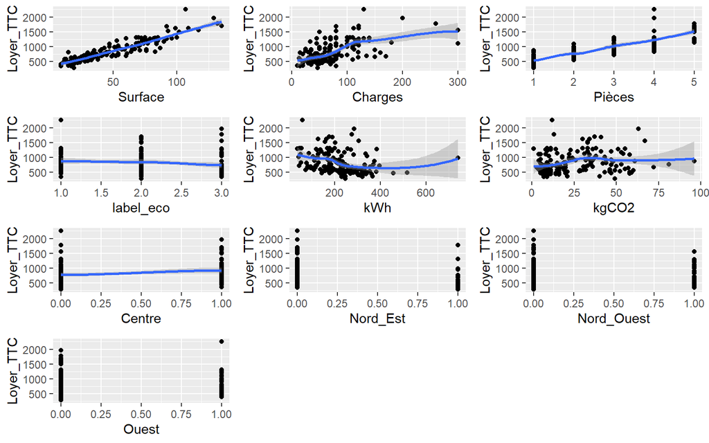

```r
graphConso <- function(uneVariable){
  ggplot(data = annonces, aes_string(x = uneVariable, y = "Loyer_TTC")) + geom_point() + geom_smooth()
}

p1 <- graphConso("Surface")
p2 <- graphConso("Charges")
p3 <- graphConso("Pièces")
p4 <- graphConso("label_eco")
p5 <- graphConso("kWh")
p6 <- graphConso("kgCO2")

p7 <-graphConso("Centre")
p8 <-graphConso("Nord_Est")
p9 <-graphConso("Nord_Ouest")
p10 <-graphConso("Ouest")

grid.arrange(p1, p2, p3, p4, p5, p6 , p7,p8,p9,p10, ncol = 3)
```

### c) Corrélations entre les variables explicatives

L’analyse de la matrice de corrélation entre les variables explicatives permet de détecter d’éventuels problèmes de multicolinéarité dans le futur modèle de régression.

# **4. Analyse et discussion des résultats**

## 4.2 Analyses complémentaires

# **5. Conclusion générale et perspectives**

# Bibliographie - Source des données

- https://ec.europa.eu/eurostat/fr/web/main/data
- https://statistiques-locales.insee.fr/#c=home